# Rationale

### 140201, Mass spectrometry

#### Input data

Score and coverage data associated to protein accession number come form Susann Mudrich.

- Four experimental conditions:
  - Control
  - IL27
  - Calprotectin
  - IL27 + Calprotectin
- The time series consists in
  - 6h
  - 12h
  - 24h
- 9 biological replicates

A summary of the row data is available below:

```
##    Accession         Score             Coverage
##  A4QPB0 :   36   Min.   :   0.000   Min.   :  0.12
##  A8K486 :   36   1st Qu.:   3.708   1st Qu.:  7.34
##  A8K9B9 :   36   Median :   8.154   Median : 13.64
##  A8K9J7 :   36   Mean   :  26.586   Mean   : 17.44
##  B2R5U1 :   36   3rd Qu.:  22.500   3rd Qu.: 23.96
##  B2R8A2 :   36   Max.   :1662.036   Max.   :100.00
##  (Other):36803
##             Condition         Time     Replicate
##  calprotectin    :9601   Min.   :6   Min.   :1.000
##  control         :9890   1st Qu.:6   1st Qu.:3.000
##  IL27            :8763   Median :6   Median :5.000
##  IL27calprotectin:8765   Mean   :6   Mean   :4.869
##                          3rd Qu.:6   3rd Qu.:7.000
##                          Max.   :6   Max.   :9.000
##
```

Unique accession numbers are distrubted across replicates as follows:

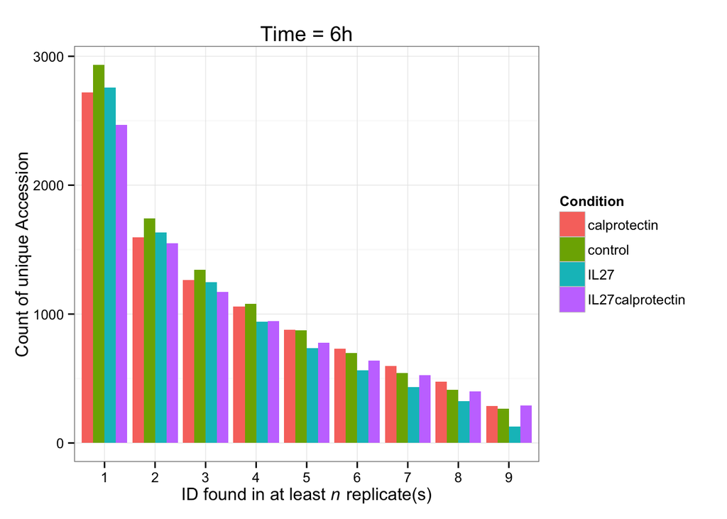

#### Filtering for protein presence across replicates

Filtering can be dynamically be changed. By default, one protein must be found in at least `5` replicates for each condition. This means that it must be found associated with at least `20` Scores for each of the `4` conditions.  
We notice that replicate 7 for IL27 reported twice as less proteins than the other replicates. Moreover, it appeared as an outlier and then was subsequently discarded.

#### Imputation of missing values

Only `90` proteins are common to all replicates for all conditions. If the above filtering is less stringent, missing data are introduced. Those `NA` can be impute from neighbors data using the R bioconductor package `impute` and the function `impute.knn`.  
This function is used with default arguments displayed below:

```r
# Usage
impute.knn(data ,k = 10, rowmax = 0.5, colmax = 0.8, maxp = 1500, rng.seed=362436069)
# data
An expression matrix with genes in the rows, samples in the columns
# k
Number of neighbors to be used in the imputation (default=10)
# rowmax
The maximum percent missing data allowed in any row (default 50%). For any rows with more than rowmax% missing are imputed using the overall mean per sample.
# colmax
The maximum percent missing data allowed in any column (default 80%). If any column has more than colmax% missing data, the program halts and reports an error.
# maxp
The largest block of genes imputed using the knn algorithm inside impute.knn (default 1500); larger blocks are divided by two-means clustering (recursively) prior to imputation. If maxp=p, only knn imputation is done.
```

#### Variance stabilization

It is performed using the the R package `vsn` and the function `vsn2`. The variance can be visualized before and after correction.

#### Contrast analysis

The constrat is derived from the RNA-seq analysis and uses the R bioconductor package `limma`. And code from Enrico Glaab:

```r
# code from Enrico Glaab
contrasts_limma <- function(dat, groups, ID, control, treatment){

  design <- model.matrix(~ -1 +
                        factor(letters[ifelse(groups[c(which(groups == control),
                               which(groups == treatment))] == control, 0, 1) + 1]))

  outnum <- as.vector(ifelse(groups[c(which(groups == control),
                                      which(groups == treatment))] == control,
                             0, 1))
  colnames(design) <- unique(letters[outnum + 1])

  corfit <- duplicateCorrelation(dat[,c(which(groups == control),
                                        which(groups == treatment))],
                                 design,
                                 block = ID)
  #corfit$consensus
  fit <- lmFit(dat[,c(which(groups == control),
                         which(groups == treatment))],
               design,
               block = ID,
               correlation = corfit$consensus)

  cm <- makeContrasts(comp = b - a, levels = design)
  fit2 <- contrasts.fit(fit, cm)
  return(eBayes(fit2))
}
```

#### Output tables

Be default, the top 20 entries, sorted by the adjusted p-values are displayed.